# Лабораторная работа №2

## Янаков Дмитрий, 317 группа

## 08.05.2022

## 1. Постановка задачи

Требуется разработать и реализовать программу для классификации изображений ладоней. Этапы работы программы:

1. Считывание и вывод (по желанию) на экран входных изображений;
2. Обработка изображений. В неё входят:

   (a) Сегментация изображений, которая заключается в нахождении кончиков пальцев и их оснований;

   (b) Определение $«позы»^{1}$ ладоней;

   (c) Определение $«линии \ пальцев»^{2}$ ладоней.
3. Вывод на экран изображений с результатом обработки.

$^{1}$Поза ладони определяется по расположению сомкнутых пальцев. Пальцы нумеруются от 1 до 5, начиная с большого пальца против часовой стрелки. Поза ладони описывается кодом 1∗2∗3∗4∗5, где значок « ∗ » обозначает « − », если пальцы разомкнуты, или « + », если они прижаты друг к другу.

$^{2}$Линия пальцев – ломаная линия, соединяющая точки на кончиках пальцев с точками в основаниях пальцев. Такая линия имеет 9 вершин и 8 звеньев.

Пример результата представлен на картинке ниже.

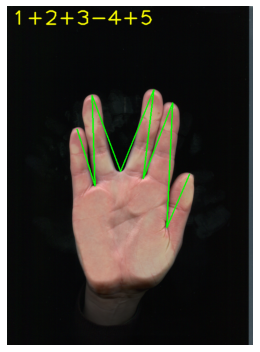

## 2. Описание данных

Входом программы являются изображения ладоней разных людей, полученных с помощью сканера, в формате 489×684 (стоит отметить, что с таким форматом в обучающей выборке было всего лишь одно изображение, все остальные были в формате 510х702, поэтому программа ориентирована больше на формат 510х702) с разрешением 72 dpi.

Примеры таковых изображены на Рис.1.

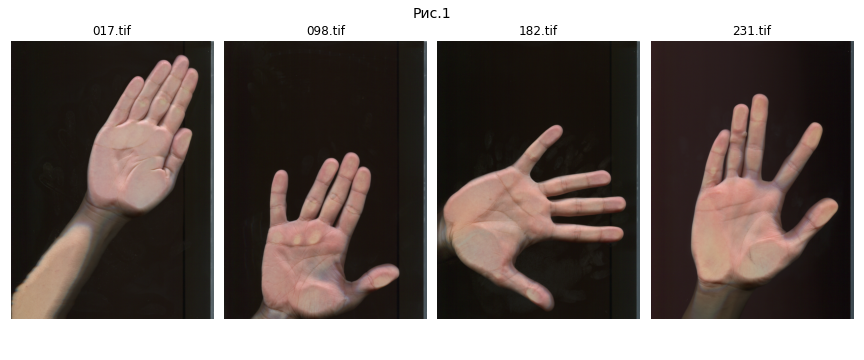

## 3. Метод решения

Решение может быть разделено на три этапа:

1. разметка изображений;
2. обучение свёрточной нейронной сети на размеченных данных из обучающей выборки (здесь и далее в качестве обучающей выборки будут выступать 63 изображения из 67 представленных для решения задачи, за исключением тех, которые изображены на Рис.1) и последующее её применение;
3. определение кончиков пальцев, их оснований, а также позы ладони.

### Этап 1

Разметим обучающую выборку (иначе говоря, создадим маски для наших изображений).

В качестве маски изображения руки будет выступать 9 окружностей радиуса 15 пискелей: 5 из них расположены на кончиках пальцев, а 4 - на их основаниях.

Примеры масок изображены на Рис.2.

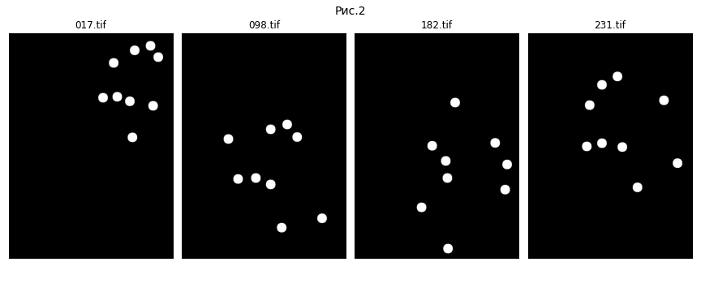

### Этап 2

В качестве свёрточной нейронной сети была выбрана сеть [UNet](https://arxiv.org/pdf/1505.04597.pdf) с энкодером из первых блоков **VGG13**, предобученного на датасете **ImageNet**.

Обучение сети происходило при помощи кросс-энтропии. Метрикой выступала IoU.

Количество эпох было **90**, и по итогу были получены следующие результаты:

- значение кросс-энтропии = **0.02**;
- значение IoU = **0.73**.

Помимо этого, к обучающей выборке применялись различные аугментации, а именно:

- случайное (с вероятностью 𝑝) горизонтальное отображение изображения;
- случайное (с вероятностью 𝑝) вырезание фрагмента изображения (заданного размера);
- случайное (с вероятностью 𝑝) изменение яркости изображения (на случайную величину).

Отметим, что в сети **UNet** понижение размерности изображения происходит 4 раза, и каждый раз размерность (как ширина, так и длина) уменьшается в 2 раза (иначе говоря, делается **max pooling** с окном **2х2**), поэтому была принята следующая стратегия обработки каждого изображения (как из обучающей выборки, так и из тестовой):

1. поскольку почти все изображения имеют размер **510х702**, то к каждому изображению был применен **padding** в **1** (чёрный) пиксель с каждой стороны, что позволило увеличить разрешение до **512x704**, которое уже удовлеторяло условиям деления в сети;
2. далее каждое изображение растягивалось до разрешения **512x704**. Тем самым, изображения, которые уже имели такой размер (а их большинство) - не менялись, а другие также начинали удовлетворять условиям деления в сети.

Применим сеть к тестовым объектам (которые изображены на Рис.1).

Результат показан на Рис.3.

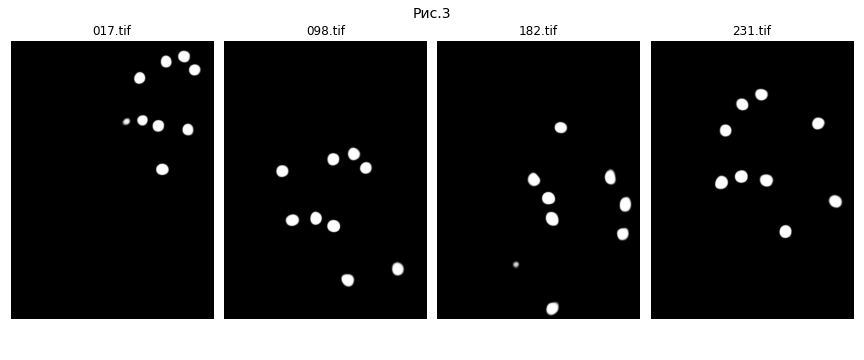

Можно заметить, что большинство точек находятся достаточно уверенно, однако есть и такие, которые имеют малый размер и менее яркие (к слову, нейросеть может находить совсем маленькие участки, вплоть до размера в 1 пиксель, но такие участки впоследствии отсеиваются).

### Этап 3

Как можно было заметить, результат работы нейронной сети не является маской (поскольку точки обладают различной яркостью). Для преобразования в маску, бинаризуем полученную матрицу по заданному порогу.

Теперь, когда у нас есть маска, можно найти координаты 9-ти необходимых точек:

1. отсеем из маски фигуры достаточно малой площади;
2. для оставшихся найдем их центр масс.

К тому же, в дальнейшем нам понадобится центр масс самой руки. Найдём его следующим образом:

1. бинаризуем исходное изображение по некоторому заданному порогу;
2. из всех областей, полученных на изображении, выберем достаточно большую, которая будет соответствовать ладони;
3. найдём центр масс выбранной области.

Изобразим все 10 точек.

Результат показан на Рис.4. Для наглядности точки сделаны жирными.

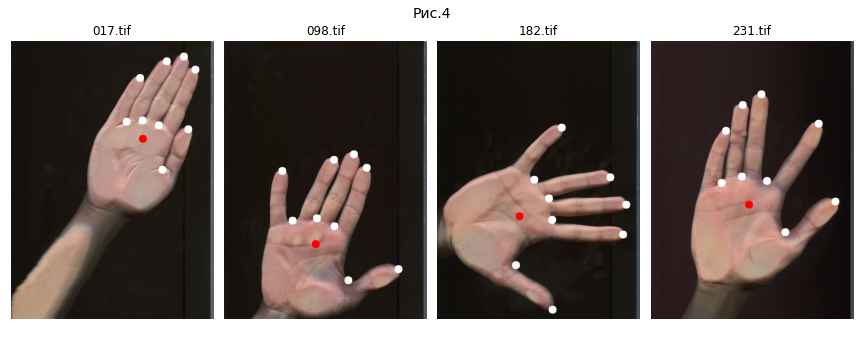

Для того, чтобы построить "линию пальцев", нужно определить принадлежность каждой из **9** точек (без центра масс ладони).

Определим основания пальцев следующим образом:

1. вычислим расстояния (здесь и далее имеется в виду евклидово расстояние) между центром масс ладони и остальными точками;
2. **4** наименьших из них будут соответствовать расстояниям между центром масс ладони и основаниями пальцев.

Следовательно, кончиками пальцев будут оставшиеся **5** точек.

Чтобы облегчить понимание следующих выкладок, введём обозначения:

- основание большого и указательного пальцев = основание БУ;
- основание указательного и среднего пальцев = основание УС;
- основание среднего и безымянного пальцев = основание СБ;
- основание безымянного пальца и мизинца = основание БМ.

Далее, чтобы определить принадлежность оснований, выполним следующую последовательность действий:

1. вычислим попарные расстояния между всеми основаниями;
2. **3** наибольших из них будут соответствовать расстояниям между основанием БУ и других оснований;
3. отсортируем эти (**3**) расстояния в порядке возрастания. Тогда получим расстояния в следующем порядке:
   1. расстояние между основанием БУ и основанием УС;
   2. расстояние между основанием БУ и основанием СБ;
   3. расстояние между основанием БУ и основанием БМ.

Теперь мы знаем принадлежность всех оснований и можем начать определять принадлежность кончиков пальцев.

Начнём с большого. Определяется он следующим образом:

1. вычисляются расстояния между основанием БУ и всех **5**-ти кончиков.
2. наименьшее из этих расстояний соответствует расстоянию между основанием БУ и коничком большого пальца.

Аналогичным образом определяется кончик мизинца, только вместо основания БУ используется основание БМ.

Кончик безымянного пальца ищется похожим образом:

1. вычисляются расстояния между кончиком мизинцца и оставшимися **4**-мя кончиками.
2. наименьшее из этих расстояний соответствует расстоянию между кончиком мизинца и кончиком безымяного пальца.

Далее, кончик указательного пальца ищется аналогично кончику безымянного, однако рассматриваются все пальцы, за исключением мизинца.

И, наконец, оставшаяся точка является кончиком среднего пальца.

Таким образом, мы определили принадлежность всех 9 точек. По ним мы можем вычислить углы между соседними пальцами и определить "позу" ладони, задав дополнительные условия на углы.

Результат работы алгоритма изображен на Рис.5.

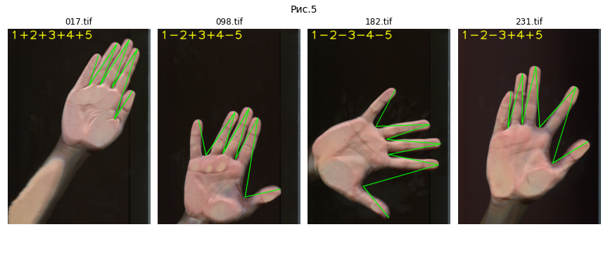

## 4. Программная реализация

Программа реализована на языке программирования **Python** с использованием **Jupyter Notebook**. Для корректной работы необходимо разместить файлы **hands.ipynb**, **model.pth** и папки **Samples**, **res** в одной директории. В папке **Samples** будут находиться тестовые изображения.

Библиотеки, использованные при реализации:

- **numpy** для матричных вычислений;
- **openCV** и **PIL** для работы с изображениями;
- **scikit-image** и **scipy** для морфологических операций над изображениями;
- **matplotlib** для работы с графиками;
- **pytorch** для работы с неройнной сетью.

Чтобы получить результат, необходимо запустить все ячейки в файле **hands.ipynb**, за исключением первого блока с названием **"GoogleColab"**, про который отдельно оговорено в файле. Изображения с нанесенной на них разметкой (как на Рис.5) будут находиться в папке **res** с названиями **res_НАЗВАНИЕ_ВХОДНОГО_ФАЙЛА.png**, однако результат можно также посмотреть в ноутбуке.

Пример работы программы приведён на картинке ниже.

[figure not shown]

Кроме этого, результат работы программы оформляется в виде файла **Results.txt** следующего формата:

- первая строка – код позы ладони, описывающий сжатые и разомкнутые пальцы: 1∗2∗3∗4∗5;
- вторая строка – координаты точек ломаной линии пальцев: **!,НАЗВАНИЕ_ВХОДНОГО_ФАЙЛА,T Xt1 Yt1,T Xt2 Yt2,T Xt3 Yt3,T Xt4 Yt4,T Xt5 Yt5,V Xv1 Yv1,V Xv2 Yv2,V Xv3 Yv3,V Xv4 Yv4,?** (где (**Xti**, **Yti**) и (**Xvi**, **Yvi**) – координаты пикселей i-й найденной точки, определяющих кончики пальцев T и основания пальцев V).

И координаты кончиков пальцев, и координаты оснований идут в следующем порядке: от большого пальца к мизинцу.

## 5. Эксперименты

Возьмём следующие изображения, на которых будет видна, как корректная, так и некорректная работа алгоритма:

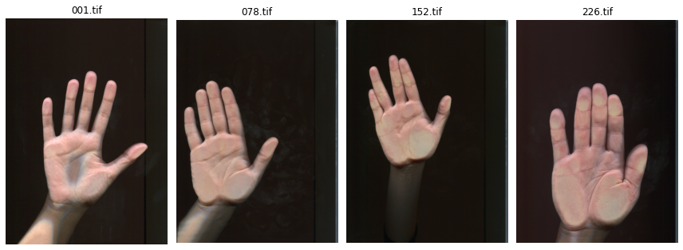

Рассмотрим полученный результат:

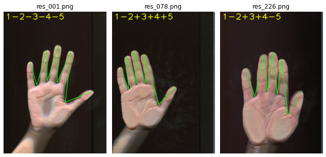

Сразу заметим, что результата для изображения **152.tif** не наблюдается. Рассмотрим этот случай чуть позже.

Изображение **res_001.png** иллюстрирует корректную работу программы. "Линия руки" и "поза" ладони определились верно. Стоит отметить, что на всех изображениях, на которых удалось получить результат, "линия руки" определилась правильно.

На изображениях **078.tif** и **226.tif** "поза" ладони определилась неверно, а именно: в первом случае мизинец разжат, однако результат показывает обратное; во втором случае аналогичная ситуация для большого пальца, только он прижат.

Очевидно, это связано с тем, что нет уникального порога для угла, который будет корректно определять для всех пальцев разжаты они или нет. Конечно, каждый человек по-своему уникален: у кого-то пальцы толще, у кого-то уже, у кого-то длиннее, а у кого-то короче.

Однако стоит отметить следующее: некорректность наблюдалась для промежутков 1∗2 и 4∗5. Промежуток 2∗3∗4 на всех изображениях, для которых был получен результат, определялся корректно. Правда есть случаи, где оценка прижатости была достаточно субъективной и по изображению нельзя было однозначно сказать разжаты пальцы или нет.

Вернёмся к изображению **152.tif**. Почему для него не был получен результат?

Всё дело в результате работы нейронной сети, который приведён ниже.

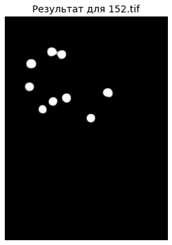

Можно заметить, что кончики указательного и среднего пальцев склеелись, поэтому при бинаризации (даже при маленьких порогах), выходит 8 контуров, а не 9. Следовательно, дальнейшая работа программы невозможна.

Из предоставленных данных только на 2-х изображениях наблюдалась подобная ситуация.

## 6. Выводы

Итак, по результатам данной лабораторной работы, была получена программа для классификации изображений ладоней. Подход, использованный при реализации, соответствует обучению с учителем, поскольку для обучения нейронной сети нужна была разметка исходных изображений. С одной стороны, для этого необходимо потратить время на настройку и обучение сети (хоть это и делается единожды), но с другой стороны, качество классификации получается достаточно хорошим, даже учитывая все нюансы из экспериментов.